# Intro to Joins

In this lesson we will be discussing joins. Consider the following two simple tables.

transactions

users

| transaction_id | user_id |
| --- | --- |
| 1 | 1 |
| 2 | 1 |
| 3 | 2 |
| 4 | 3 |
| 5 | 4 |

| user_id | name |
| --- | --- |
| 1 | Chris |
| 2 | John |
| 3 | Katie |
| 5 | Sarah |

Joining tables means to **JOIN** columns from one table onto another table given some join condition/criteria. This is typically done when there is a column or set of columns in common between tables. Although that does not have to be the case in more complex examples. We will keep it simple here for now.

In the example above, for each transaction in the **transactions** table we may want to know the name of the user associated with the **user_id**. We can get the name from the **users** table by joining the **transactions** table and **users** table ON **user_id** since this column is common between the two tables.

Note that we are missing one **user_id** (user_id=4) which appears in the **transactions** table but not in the **users** table. There is also a **user_id** in the **users** table (user_id=5) which does not appear in the **transactions** table. That is supposed to be the case for these simple examples. We want to show what happens to these types of records for different types of joins.

# Some Common Types of Joins

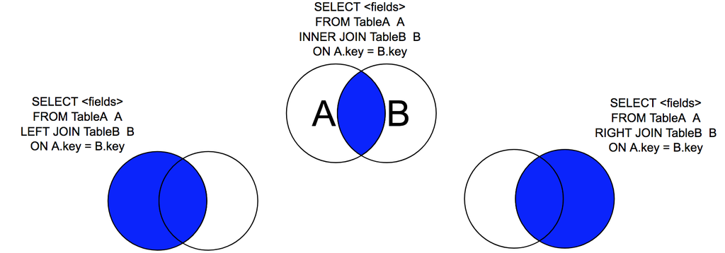

Common Types of Joins

- There are other types of joins as well such as cross joins and outer joins. We can explain these in later lessons. The far most common joins are the inner join and the left join. The right join can be obtained by switching the order of the tables in the SQL statement and simply using a left join. I personally rarely use right joins. I stick to inner joins and left joins for most use cases. I have attached these diagrams just in case they help your understanding more in the following examples. If they do not, that is fine too. The main thing to come away with here is the difference between an **inner join** and a **left join**. A **right join** can be replaced with a **left join** if the tables are switched in the order they are joined as you will soon see.

## Inner Join

*The INNER JOIN selects all rows/records from both participating tables as long as there is a match between the columns.*

Lets do an inner join between the **transactions** table and the **users** table on **user_id**. An **inner join** keeps all the records for which the **join condition** is met in both tables. In this example, it means that if there is a **user_id** which exists in both the **transactions** table and **users** table, then the corresponding records will be in the final result after joining.

When joining two tables you alias both tables. Here we will used an alias of **t** on the **transactions** table and an alias of **u** on the **users** table. We can then use the alias of each table within the **SELECT** statement as well as the **ON** statement. The **ON** statement specifies the logic to join on. In the **SELECT** statement we specify which columns we want from either table. Here we are simply joining where the **user_id** from the two tables are equal.

Here are the two tables again so you do not have scroll up.

transactions **(t)**

users **(u)**

| transaction_id | user_id |
| --- | --- |
| 1 | 1 |
| 2 | 1 |
| 3 | 2 |
| 4 | 3 |
| 5 | 4 |

| user_id | name |
| --- | --- |
| 1 | Chris |
| 2 | John |
| 3 | Katie |
| 5 | Sarah |

Here is the inner join between the two tables using an **inner join** on **user_id**.

```sql
SELECT
    t.transaction_id,
    t.user_id,
    u.user_id as user_id_from_users_table,
    u.name
FROM
    transactions t
JOIN
    users u
ON
    t.user_id = u.user_id
```

Note that we can not select the **user_id** from both tables in our select statement unless we change the name of at least one in the final result. This is because you can not have two columns with the same name in a query. Usually you would just return the **user_id** from only one of the tables anyway since they will be equal after doing the join. We have returned both and renamed one just to drive home the point that records must match on **user_id**.

Also note that we do not have to write **INNER JOIN** in the query, although we can if we want. But if we simply write **JOIN** it will do an inner join by default. The **t.** and **u.** are used to alias and select columns from the **transactions** table and **users** table respectively.

The above inner join query returns this result:

| transaction_id | user_id | user_id_from_users_table | name |
| --- | --- | --- | --- |
| 1 | 1 | 1 | Chris |
| 2 | 1 | 1 | Chris |
| 3 | 2 | 2 | John |
| 4 | 3 | 3 | Katie |

## Left Join

*The LEFT JOIN keyword returns all records from the left table (**transactions**), and the matched records from the right table (**users**). The result is NULL from the right side, if there is no match.*

Here are the two tables again so you do not have scroll up.

transactions **(t)**

users **(u)**

| transaction_id | user_id |
| --- | --- |
| 1 | 1 |
| 2 | 1 |
| 3 | 2 |
| 4 | 3 |
| 5 | 4 |

| user_id | name |
| --- | --- |
| 1 | Chris |
| 2 | John |
| 3 | Katie |
| 5 | Sarah |

The only difference is we write **LEFT JOIN** in the query.

```sql
SELECT
    t.transaction_id,
    t.user_id,
    u.user_id as user_id_from_users_table,
    u.name
FROM
    transactions t
LEFT JOIN
    users u
ON
    t.user_id = u.user_id
```

The above left join query would return

| transaction_id | user_id | user_id_from_users_table | name |
| --- | --- | --- | --- |
| 1 | 1 | 1 | Chris |
| 2 | 1 | 1 | Chris |
| 3 | 2 | 2 | John |
| 4 | 3 | 3 | Katie |
| 5 | 4 | NULL | NULL |

## Right Join

*The RIGHT JOIN keyword returns all records from the right table (**users**), and the matched records from the left table (**transactions**). The result is NULL from the left side, when there is no match.*

The only difference is we write **RIGHT JOIN** in the query.

```sql
SELECT
    t.transaction_id,
    t.user_id,
    u.user_id as user_id_from_users_table,
    u.name
FROM
    transactions t
RIGHT JOIN
    users u
ON
    t.user_id = u.user_id
```

The above right join would return

| transaction_id | user_id | user_id_from_users_table | name |
| --- | --- | --- | --- |
| 1 | 1 | 1 | Chris |
| 2 | 1 | 1 | Chris |
| 3 | 2 | 2 | John |
| 4 | 3 | 3 | Katie |
| NULL | NULL | 5 | Sarah |

We could achieve the above same result by doing a left join and switching the order of the tables which would give the same result.

```sql
SELECT
    t.transaction_id,
    t.user_id,
    u.user_id as user_id_from_users_table,
    u.name
FROM
    users u
LEFT JOIN
    transactions t
ON
    t.user_id = u.user_id
```